# Epidemiologia de Doenças Infecciosas

Número R e a sua aplicação

Autor

Afiliação

A. Peralta-Santos

Escola Nacional de Saúde Pública

Data de Publicação

4 de junho de 2024

# 1 Introdução às doenças infecciosas

## 1.1 Interação Hospedeiro-Agente-Ambiente e Fatores que Influenciam essa Interação

**Tríade Hospedeiro-Agente-Ambiente**:

- **Hospedeiro (Host)**: a especie que manifesta a infeção ou doença.
  - **Exemplo**: No HIV/SIDA, o sistema imunológico humano é alvo do vírus.
- **Agente (Pathogen)**: O agente infeccioso (vírus, bactéria, fungo, parasita) que causa a doença.
  - **Exemplo**: Mycobacterium tuberculosis, a bactéria que causa tuberculose.
- **Ambiente (Environment)**: Fatores externos que afetam o hospedeiro e o patógeno.
  - **Exemplo**: A transmissão da malária é fortemente influenciada pela presença de água parada onde os mosquitos Anopheles se reproduzem.

**Fatores que Influenciam a Interação**:

- **Fatores do Hospedeiro**:
  - **Genética (Genetic Makeup)**: Certas mutações genéticas podem proporcionar resistência a doenças (ex.: a mutação da anemia falciforme proporciona alguma resistência à malária).
  - **Estado Imunológico (Immune Status)**: Indivíduos imunocomprometidos, como aqueles com HIV, são mais suscetíveis a infecções oportunistas.
  - **Idade (Age)**: Bebês e idosos são geralmente mais vulneráveis a infecções devido a sistemas imunológicos mais fracos.
  - **Sexo (Sex)**: Algumas doenças mostram prevalência específica por sexo (ex.: infecções do trato urinário são mais comuns em mulheres).
  - **Nutrição (Nutrition)**: A desnutrição pode enfraquecer o sistema imunológico, tornando os indivíduos mais suscetíveis a infecções como o sarampo.
  - **Comorbidades (Comorbidities)**: Condições como diabetes podem predispor indivíduos a infecções como infecções bacterianas da pele.
- **Fatores do Agente**:
  - **Virulência (Virulence)**: A capacidade de um agente causar doença grave (ex.: o vírus Ebola tem alta virulência).
  - **Dose (Dose)**: A quantidade de agente necessária para causar infecção (ex.: uma dose alta de bactérias do cólera é necessária para causar a doença).
  - **Via de Entrada (Route of Entry)**: O caminho através do qual o patógeno entra no hospedeiro (ex.: trato respiratório para a gripe).
  - **Adaptabilidade (Adaptability)**: Capacidade do agente de mutar e resistir ao tratamento (ex.: bactérias resistentes a antibióticos, alterações antigenicas do virus da gripe ou SARS-CoV-2).

### 1.1.1 Tipos de agente

| Tipo de agente | Características | Exemplos |
| --- | --- | --- |
| Microparasitas | Virus - Pequenos, simples, parasitas obrigatórios de células maiores | Sarampo, caxumba, rubéola, varíola, síndrome respiratória aguda grave (SARS), influenza |
|  | Bactérias - Maiores e mais complexas que vírus—muitas são capazes de crescer independentemente, mas algumas requerem uma célula hospedeira | Bordetella pertussis (coqueluche), Mycobacterium tuberculosis (tuberculose), Salmonella typhi (febre tifóide) |
|  | Protozoários - Organismos unicelulares maiores, mais complexos que bactérias—muitos são capazes de crescer independentemente, mas alguns requerem uma célula hospedeira | Plasmodium falciparum (malária); Entamoeba histolytica (disenteria) |
| Macroparasitas | Helmintos (vermes) - Organismos multicelulares grandes (1mm a 10m) | Schistosoma mansoni (esquistossomose) |
|  | Artrópodes - Insetos, piolhos, carrapatos e seus parentes | Ixodes spp (carrapatos) |

### 1.1.2 Tipo de transmissão e dinamica de transmissão

**Modos de Transmissão**:

- **Transmissão Direta (Direct Transmission)**: Contato pessoa a pessoa, disseminação por gotículas.
  - **Exemplo**: A gripe é transmitida por gotículas de tosse e espirro.
- **Transmissão Indireta (Indirect Transmission)**: Via intermediários como vetores.
  - **Exemplo**: A malária é transmitida por vetores mosquitos.

**Tipos de Dinamicas de transmissão de Doenças Infecciosas**:

- **Endêmica (Endemic)**: Presença constante dentro de uma área geográfica.
  - **Exemplo**: A malária é endêmica em muitas partes da África Subsaariana.
- **Epidemia (Epidemic)**: Um aumento nos casos acima do normal esperado.
  - **Exemplo**: O surto de Ebola na África Ocidental em 2014-2016.
- **Pandemia (Pandemic)**: Disseminação mundial de uma nova doença.
  - **Exemplo**: Pandemia de COVID-19.

### 1.1.3 História Natural das Doenças Infecciosas

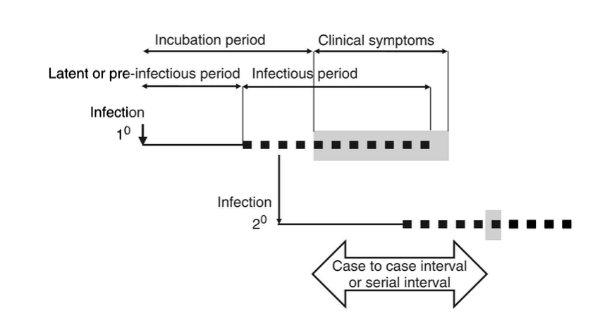

**Estágios da Doença**:

- **Período de Incubação (Incubation Period)**: Tempo entre a exposição e o início dos sintomas.
  - **Exemplo**: O período de incubação do sarampo é tipicamente de 10-14 dias.
- **Período prodromico (Prodromal Period)**: Sintomas iniciais, não específicos.
  - **Exemplo**: A fase prodromica da varicela inclui febre e mal-estar antes do aparecimento da erupção cutânea.
- **Fase Aguda (Acute Phase)**: Sintomas específicos manifestam-se.
  - **Exemplo**: A fase aguda da dengue inclui febre alta, dor de cabeça severa e dor nas articulações.
- **Convalescença (Convalescence)**: Fase de recuperação.
  - **Exemplo**: A fase de convalescença da hepatite B envolve uma melhora gradual nos sintomas e retorno à função hepática normal.

**Resultados da Infecção**:

- **Recuperação (Recovery)**: Resolução completa dos sintomas.
  - **Exemplo**: A maioria das pessoas se recupera completamente da gripe em duas semanas.
- **Infecção Crónica (Chronic Infection)**: Infecção persistente com possíveis sintomas periódicos.
  - **Exemplo**: A hepatite C pode levar a uma doença hepática crônica.
- **Infecção Latente (Latent Infection)**: Patógeno dormente com potencial de reativação.
  - **Exemplo**: O vírus Varicela-zoster pode permanecer latente e reativar-se como herpes zoster.
- **Estado de Portador (Carrier State)**: Assintomático, mas capaz de transmitir.
  - **Exemplo**: Portadores de febre tifóide podem excretar Salmonella Typhi sem sintomas.

### 1.1.4 Papel dos Mecanismos de Transmissão no Controle e Prevenção de Doenças

**Mecanismos de Transmissão**:

- **Aérea (Airborne)**: Gotículas, controle de ventilação.
  - **Exemplo**: A transmissão da TB pode ser reduzida melhorando a ventilação em ambientes de saúde.
- **Vetorial (Vector-Borne)**: Mosquitos; estratégias de controle de vetores.
  - **Exemplo**: Uso de redes de cama tratadas com inseticida para prevenir a malária.
- **Hídrica (Waterborne)**: Água contaminada; melhorias no saneamento.
  - **Exemplo**: Prevenção do cólera através do fornecimento de água e saneamento melhorados.
- **Transmissão por Alimentos (Foodborne)**: Alimentos contaminados; protocolos de segurança alimentar.
  - **Exemplo**: Prevenção de infecções por salmonela através da manipulação e cozimento adequados dos alimentos.
- **Transmissão por Contato (Contact Transmission)**: Isolamento, higiene das mãos.
  - **Exemplo**: Redução da transmissão de MRSA em hospitais através da higiene rigorosa das mãos e precauções de contato.

# 2 Introdução ao Número R

## 2.1 O que é o Número R?

O número R representa o número médio de infecções secundárias produzidas por um único indivíduo infectado em uma população totalmente suscetível. Ele é crucial para prever a propagação de doenças infecciosas.

A epidemia está se expandindo se R > 1 e se contraindo se R < 1.

Existem várias definições de R, que afetam seu valor estimado e interpretação.

Diferentes métodos estatísticos e a disponibilidade de dados podem influenciar as estimativas de R.

### 2.1.1 Distinção entre ( R_0 ) e ( R_t )

**( R_0 )**: Número básico de reprodução - o número médio de casos secundários produzidos por uma única infecção em uma população totalmente suscetível.

**( R_t )**: Número de reprodução efetivo - o número médio de casos secundários em um determinado momento ( t ), considerando o estado atual de imunidade da população e as medidas de intervenção. As estimativas de Rt podem ser estáveis em grandes surtos estabelecidos, mas variam com mudanças nas intervenções e níveis de imunidade. Alta variabilidade e heterogeneidade em níveis de baixa prevalência podem tornar Rt menos confiável.

## 2.2 Importancia do Número R

O número R ajuda a prever a potencial propagação de uma doença infecciosa e a orientar as intervenções de saúde pública para controlar surtos, reduzindo ( R ) abaixo de 1.

## 2.3 Fatores

O número R é influenciado por:

- Taxa de transmissão ( $\beta$ )
- Taxa de contato ( k )
- Duração da infecciosidade ( D )
- Imunidade da população

# 3 Calcular o Número R

## 3.1 Estrutura Matemática

A fórmula básica para ( R_0 ) é:

$$R_0 = \beta \times k \times D$$

### 3.1.1 Cálculo de Exemplo

Considere valores hipotéticos:

- Probabilidade de transmissão por contato (( $\beta$ )): 0.1
- Número de contatos por unidade de tempo (( k )): 10
- Duração da infecciosidade (( D )): 5 dias

```r
# Example calculation of R0
beta <- 0.1
k <- 10
D <- 5

R0 <- beta * k * D
R0
```

```
[1] 5
```

Qual seria o Número de Infectados depois de 3 gerações de casos com R0 de 5?

#### 3.1.1.1 O R e o processo de infecção

As definições do número de reprodução devem levar em consideração a heterogeneidade da população e a estrutura de contato.

Modelos de população estruturada (doméstico, multi-tipo, rede, modelos espaciais) capturam diferentes padrões de contato e transmissão.

Modelos domiciliares, transmissão entre grupos e modelos de rede oferecem diferentes insights sobre os valores de R.

#### 3.1.1.2 Número R, vacinação e imunidade de grupo

- À medida que a imunidade aumenta, Rt diminui, atingindo a imunidade de grupo quando Rt < 1 sem intervenções adicionais.
- A vacinação visa alcançar a imunidade de grupo reduzindo o número de suscetíveis.
- Os limiares críticos de vacinação dependem de R0 e da estrutura da população.
- As estratégias de vacinação ideais devem considerar a heterogeneidade da população e as prioridades de saúde pública.

#### 3.1.1.3 Dados usados para estimar R

Idealmente, Rt deve ser estimado a partir do total de infecções incidentes, mas os dados práticos frequentemente apresentam atrasos.

Ajustes para atrasos na observação e vieses temporais são necessários.

Diferentes fluxos de dados (casos, hospitalizações, mortes) oferecem vantagens e limitações variadas.

A estimativa requer equilibrar a relação sinal-ruído e a sensibilidade a mudanças repentinas na transmissão.

### 3.1.2 Estimando ( R_t )

Podemos estimar ( R_t ) usando dados epidemiológicos por meio de métodos como análise de séries temporais e inferência Bayesiana.

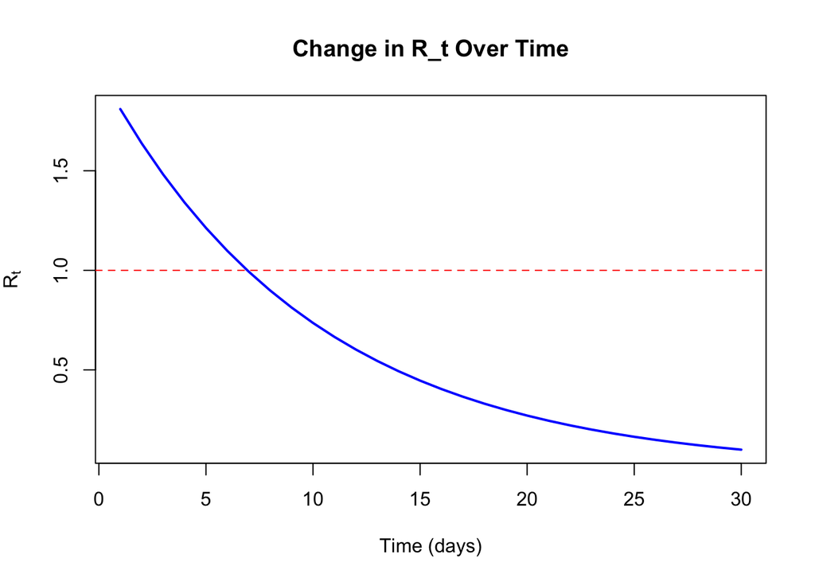

```r
# Simulated data for R_t estimation
time <- 1:30
Rt <- 2 * exp(-0.1 * time)

plot(time, Rt, type = "l", col = "blue", lwd = 2,
     xlab = "Time (days)", ylab = expression(R[t]),
     main = "Change in R_t Over Time")
abline(h = 1, col = "red", lty = 2)
```

## 3.2 Como o número de contatos afeta o Rt

A análise de sensibilidade ajuda a entender como as mudanças nos parâmetros (por exemplo, taxa de contato, probabilidade de transmissão) afetam o número R.

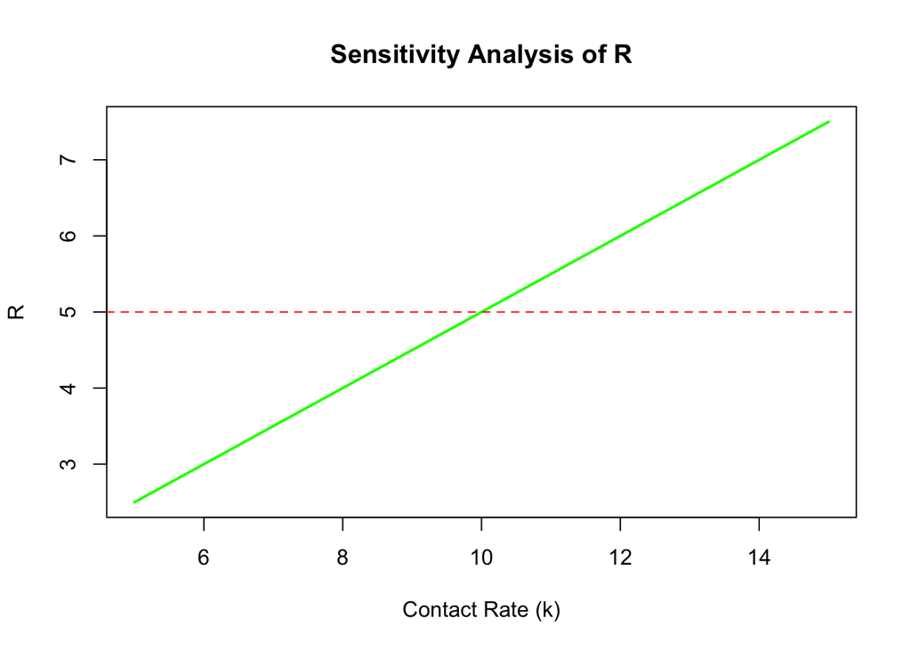

```r
# Sensitivity analysis
contact_rate <- seq(5, 15, by = 1)
R_sensitivity <- beta * contact_rate * D

plot(contact_rate,
     R_sensitivity,
     type = "l", col = "green", lwd = 2,
     xlab = "Contact Rate (k)", ylab = expression(R),
     main = "Sensitivity Analysis of R")
abline(h = R0, col = "red", lty = 2)
```

## 3.3 Matriz de Contatos

O estudo fornece matrizes de contato que podem ser usadas para entender os padrões de interação entre diferentes faixas etárias.

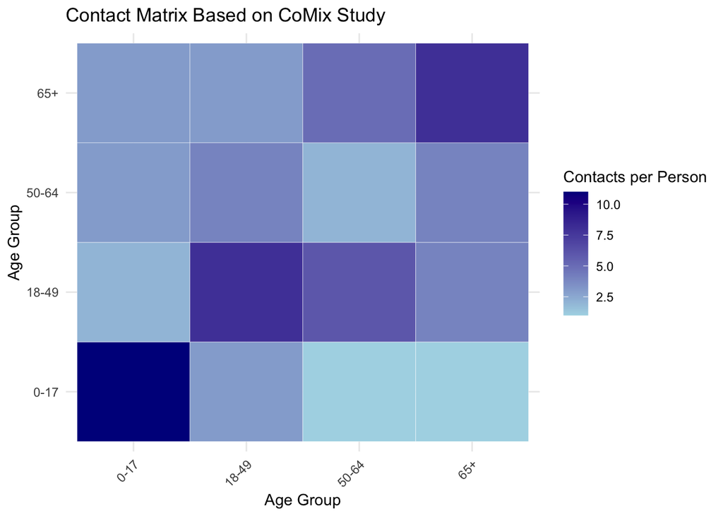

```r
library(Matrix)
library(ggplot2)
library(reshape2)

# Example contact matrix based on CoMix study
contact_matrix <- matrix(c(
  11, 3, 1, 1,
  2, 8, 6, 4,
  3, 4, 2, 4,
  3, 3, 5, 8
), nrow = 4, byrow = TRUE)

# Age groups corresponding to the matrix
age_groups <- c("0-17", "18-49", "50-64", "65+")

# Convert matrix to a dataframe for ggplot
contact_df <- melt(contact_matrix)
colnames(contact_df) <- c("AgeGroup1", "AgeGroup2", "Contacts")
contact_df$AgeGroup1 <- factor(contact_df$AgeGroup1, labels = age_groups)
contact_df$AgeGroup2 <- factor(contact_df$AgeGroup2, labels = age_groups)

# Plot the contact matrix
ggplot(contact_df, aes(x = AgeGroup2, y = AgeGroup1, fill = Contacts)) +
  geom_tile(color = "white") +
  scale_fill_gradient(low = "lightblue", high = "darkblue") +
  theme_minimal() +
  labs(title = "Contact Matrix Based on CoMix Study",
       x = "Age Group",
       y = "Age Group",
       fill = "Contacts per Person") +
  theme(axis.text.x = element_text(angle = 45, hjust = 1))
```

## 3.4 Vacinação e o Número R

**Limite da Imunidade de Grupo:**

A vacinação de uma proporção uniformemente escolhida aleatoriamente

$$1 - \frac{1}{R0}$$

da população é suficiente para criar imunidade de grupo e prevenir uma epidemia, desde que a imunidade induzida pela vacina seja suficientemente duradoura.

**Cálculos Simples de Exemplo:**

Se (R0 = 2), então 50% da população precisa ser vacinada ou estar imune para prevenir surtos.

$$1 - \frac{1}{2}$$
$$0.5= 50%$$

Se (R0 = 3), como é aproximadamente o caso da COVID-19, então 67% da população precisa ser vacinada ou imune.

$$1 - \frac{1}{3}$$
$$0.67= 67%$$

**Imunossenescência**

Ao definir metas de vacinação, a imunossenescência deve ser levada em consideração. Por exemplo, se a imunidade proporcionada por uma vacina diminui ao longo do tempo, doses de reforço podem ser necessárias para manter a imunidade de grupo

**Impacto do Momento da Vacinação**

A implementação e o impacto de um programa de vacinação dependem de se a vacinação é realizada antes ou durante um surto:

**Antes de um Surto:** Prevê a ocorrência do surto ou reduz significativamente sua propagação.

Exemplo: Campanhas de vacinação contra a poliomielite que visam manter altos níveis de imunidade na população para prevenir surtos.

**Durante um Surto:** Ajuda a controlar e eventualmente parar a propagação da doença.

Exemplo: O rápido desenvolvimento e distribuição de vacinas contra a COVID-19 durante a pandemia para reduzir a transmissão e a gravidade da doença.

**Considerações Adicionais:**

Estrutura Populacional: A eficácia de se alcançar a imunidade de grupo pode variar com base na estrutura populacional e nos padrões de contato. Por exemplo, a vacinação direcionada a grupos de alto contato pode ser mais eficaz.

Exemplo: Priorização de profissionais de saúde e populações idosas durante a campanha de vacinação contra a COVID-19.

Cobertura e Hesitação vacinal: Alcançar a cobertura vacinal necessária exige abordar a hesitação vacinal e garantir o acesso equitativo às vacinas.

Exemplo: Campanhas de saúde pública para educar e encorajar a adesão à vacinação entre grupos hesitantes.

**Exemplos do Mundo Real:**

**Sarampo:** O sarampo tem um R0 alto de cerca de 12-18, o que significa que mais de 95% da população precisa ser vacinada para alcançar a imunidade de grupo. Esforços de vacinação contínuos visam manter esse nível para prevenir surtos.

**Gripe:** Programas de vacinação contra a gripe sazonal visam vacinar populações vulneráveis a cada ano para mitigar o impacto dos surtos anuais, considerando a variação na eficácia e nas taxas de cobertura.

## 3.5 Aplicação Prática e Discussão

epiparameter é um pacote R que contém uma biblioteca de parâmetros epidemiológicos para doenças infecciosas e um conjunto de classes e funções auxiliares para trabalhar com os dados. Também inclui funções para extrair e converter parâmetros de estatísticas resumidas relatadas. [link para o epiparameter](https://epiverse-trace.github.io/epiparameter/)

Lista de distribuições epidemiológicas:

“all”

“incubation period”

“onset to hospitalisation”

“onset to death”

“serial interval”

“generation time”

“offspring distribution”

“hospitalisation to death”

“hospitalisation to discharge”

“notification to death”

“notification to discharge”

“onset to discharge”

“onset to ventilation”

```r
# check whether {pak} is installed
if(!require("pak")) install.packages("pak")
pak::pak("epiverse-trace/epiparameter")
```

[output not shown]

[output not shown]

[output not shown]

[output not shown]

[output not shown]

```r
library(epiparameter)
```

```r
epidists <- epidist_db()
```

```
Returning 122 results that match the criteria (99 are parameterised).
Use subset to filter by entry variables or single_epidist to return a single entry.
To retrieve the citation for each use the 'get_citation' function
```

```r
influenza_generation <- epidist_db(
  disease = "influenza",
  epi_dist = "generation time",
  single_epidist = TRUE
)
```

```
Using Lessler J, Reich N, Cummings D, New York City Department of Health and
Mental Hygiene Swine Influenza Investigation Team (2009). "Outbreak of
2009 Pandemic Influenza A (H1N1) at a New York City School." _The New
England Journal of Medicine_. doi:10.1056/NEJMoa0906089
<https://doi.org/10.1056/NEJMoa0906089>..
To retrieve the citation use the 'get_citation' function
```

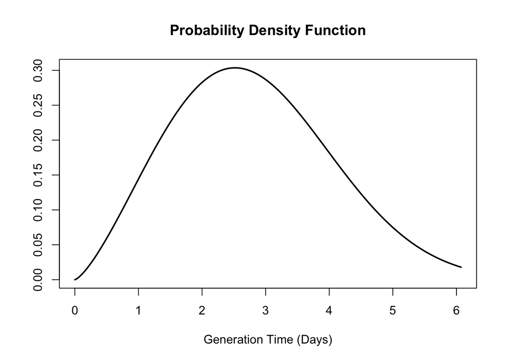

```r
plot(influenza_generation)
```

```r
covid_incubation <- epidist_db(
  disease = "covid",
  epi_dist = "incubation period",
  single_epidist = TRUE
)
```

```
Using Linton N, Kobayashi T, Yang Y, Hayashi K, Akhmetzhanov A, Jung S, Yuan
B, Kinoshita R, Nishiura H (2020). "Incubation Period and Other
Epidemiological Characteristics of 2019 Novel Coronavirus Infections
with Right Truncation: A Statistical Analysis of Publicly Available
Case Data." _Journal of Clinical Medicine_. doi:10.3390/jcm9020538
<https://doi.org/10.3390/jcm9020538>..
To retrieve the citation use the 'get_citation' function
```

```r
covid_incubation
```

```
Disease: COVID-19
Pathogen: SARS-CoV-2
Epi Distribution: incubation period
Study: Linton N, Kobayashi T, Yang Y, Hayashi K, Akhmetzhanov A, Jung S, Yuan
B, Kinoshita R, Nishiura H (2020). "Incubation Period and Other
Epidemiological Characteristics of 2019 Novel Coronavirus Infections
with Right Truncation: A Statistical Analysis of Publicly Available
Case Data." _Journal of Clinical Medicine_. doi:10.3390/jcm9020538
<https://doi.org/10.3390/jcm9020538>.
Distribution: lnorm
Parameters:
  meanlog: 1.525
  sdlog: 0.629
```

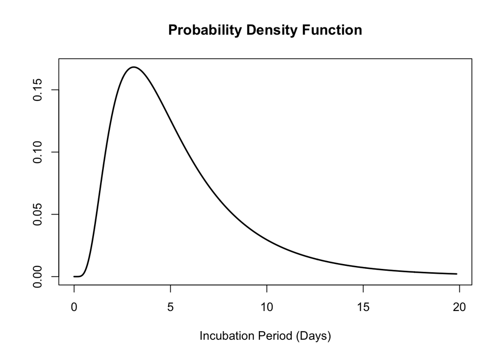

```r
plot(covid_incubation)
```

## 3.6 Exemplo de Geração de Rt

```r
library(EpiEstim)
library(readr)
library(ggplot2)
```

```r
## load data
data(Flu2009)
## incidence:
head(Flu2009$incidence)
```

```
       dates I
1 2009-04-27 1
2 2009-04-28 1
3 2009-04-29 0
4 2009-04-30 2
5 2009-05-01 5
6 2009-05-02 3
```

```r
## serial interval (SI) distribution:
Flu2009$si_distr
```

```
 [1] 0.000 0.233 0.359 0.198 0.103 0.053 0.027 0.014 0.007 0.003 0.002 0.001
```

```r
## interval-ceonsored serial interval data:
## each line represents a transmission event,
## EL/ER show the lower/upper bound of the symptoms onset date in the infector
## SL/SR show the same for the secondary case
## type has entries 0 corresponding to doubly interval-censored data
## (see Reich et al. Statist. Med. 2009).
head(Flu2009$si_data)
```

```
  EL ER SL SR type
1  0  1  7  8    0
2  0  1  2  3    0
3  0  1  3  4    0
4  0  1  2  5    0
5  0  1  1  9    0
6  0  1  2  4    0
```

```r
res_parametric_si <- estimate_R(Flu2009$incidence,
                                method="parametric_si",
                                config = make_config(list(
                                  mean_si = 2.6,
                                  std_si = 1.5))
)
```

```
Default config will estimate R on weekly sliding windows.
    To change this change the t_start and t_end arguments.
```

```r
head(res_parametric_si$R)
```

```
  t_start t_end  Mean(R)    Std(R) Quantile.0.025(R) Quantile.0.05(R)
1       2     8 1.735798 0.4091314         1.0287437         1.121933
2       3     9 1.749168 0.3647267         1.1088223         1.195480
3       4    10 1.537058 0.3074116         0.9947030         1.068694
4       5    11 1.431839 0.2705921         0.9514466         1.017661
5       6    12 1.422725 0.2515046         0.9731426         1.035808
6       7    13 1.635373 0.2523436         1.1786332         1.243590
  Quantile.0.25(R) Median(R) Quantile.0.75(R) Quantile.0.95(R)
1         1.445198  1.703761         1.991520         2.458972
2         1.491345  1.723884         1.979457         2.389121
3         1.320090  1.516613         1.731761         2.075176
4         1.241251  1.414830         1.603900         1.904047
5         1.245996  1.407932         1.583340         1.860107
6         1.458847  1.622413         1.797779         2.071372
  Quantile.0.975(R)
1          2.624781
2          2.533119
3          2.195540
4          2.008849
5          1.956336
6          2.165745
```

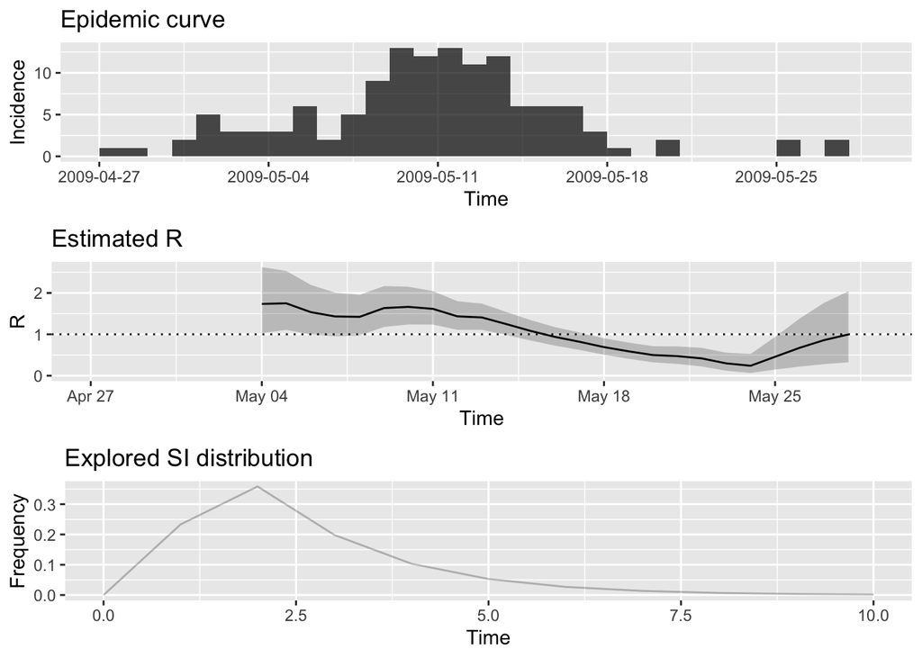

```r
plot(res_parametric_si, legend = FALSE)
```

# 4 Modelos

*Fonte: An Introduction to Infectious Disease Modelling, Richard White, 2015*

> All models are wrong, some are usefull

Os modelos começam com uma descrição (simples) do assunto em estudo e passam a descrever os elementos essenciais que determinam o comportamento na vida real.

A oportunidade que os modelos oferecem para analisar um assunto complexo é em si um dos benefícios importantes de uma abordagem de modelagem - o modelo torna-se, na verdade, uma estrutura lógica que imita o mundo real.

Se este processo for considerado com cuidado e as características mais importantes do fenómeno forem conhecidas, então o modelo poderá fornecer uma representação realista do mundo real.

Se o modelo acabar por não se comportar como o mundo real, então isto é uma prova de que os seus pressupostos básicos estavam errados ou insuficientes de alguma forma importante ou que algo se alterou nos presupostos.

## 4.1 Questões relevantes a considerar

Ao desenvolver um modelo, é importante começar com as principais características da epidemiologia da infecção, tais como:

1. Qual é o período pré-infeccioso (o período de tempo entre a infecção e o início da infecciosidade, muitas vezes chamado de período “latente”) ?
2. Durante quanto tempo os indivíduos são normalmente infecciosos?
3. Qual é o número básico de reprodução?
4. Todos os grupos etários (ou outros grupos sociais) são igualmente afectados pela infecção?

Existem três considerações principais ao considerar a estrutura do modelo:

**A história natural da infecção.**

**A precisão e o período de tempo durante os quais as previsões do modelo são necessárias.**

**A pergunta de investigação**

## 4.2 Tipos de modelos

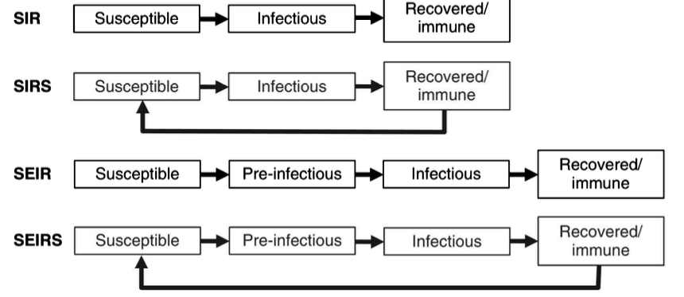

Os modelos podem ser determinísticos ou estocásticos.

Os modelos determinísticos descrevem o que acontece “em média” numa população. Nesses modelos, os parâmetros de entrada (por exemplo, a taxa de início da doença ou a taxa de recuperação das pessoas) são fixos e, portanto, as previsões do modelo, como o número de casos que serão vistos ao longo do tempo, são ‘pré-determinados’.

Os modelos estocásticos, por outro lado, permitem que o número de indivíduos que se movem entre os compartimentos varia ao acaso, por exemplo, a taxa à qual as pessoas são infectadas ou os indivíduos infecciosos recuperam da doença pode variar aleatoriamente.

## 4.3 Modelos SIR

O modelo SIR é um dos modelos mais simples e fundamentais na epidemiologia matemática.

Ele é usado para descrever a propagação de doenças infecciosas em uma população. SIR é um acrônimo para **Susceptible-Infectious-Recovered** (Suscetíveis-Infectados-Recuperados), os três compartimentos principais do modelo. A ideia é dividir a população em três grupos (ou compartimentos):

1. **Suscetíveis (S)**: Indivíduos que ainda não foram infectados pela doença e são vulneráveis à infecção.
2. **Infectados (I)**: Indivíduos que estão atualmente infectados e podem transmitir a doença aos suscetíveis.
3. **Recuperados (R)**: Indivíduos que já foram infectados, se recuperaram e agora são imunes à reinfecção.

[output not shown]

### 4.3.1 Equações Diferenciais do Modelo SIR

As mudanças nas populações desses três grupos ao longo do tempo são descritas por um sistema de equações diferenciais ordinárias (EDOs):

1. $\frac{dS}{dt} = -\beta \frac{IS}{N}$: A taxa de mudança na população suscetível. A diminuição é proporcional ao produto de indivíduos suscetíveis e infectados, modulado pela taxa de transmissão $\beta$.
2. $\frac{dI}{dt} = \beta \frac{IS}{N} - \gamma I$: A taxa de mudança na população infectada. O aumento é proporcional ao número de contatos infecciosos $\beta \frac{IS}{N}$, enquanto a diminuição é proporcional à recuperação dos infectados $\gamma I$.
3. $\frac{dR}{dt} = \gamma I$: A taxa de mudança na população recuperada. Esta aumenta conforme os indivíduos infectados se recuperam, modulado pela taxa de recuperação $\gamma$.

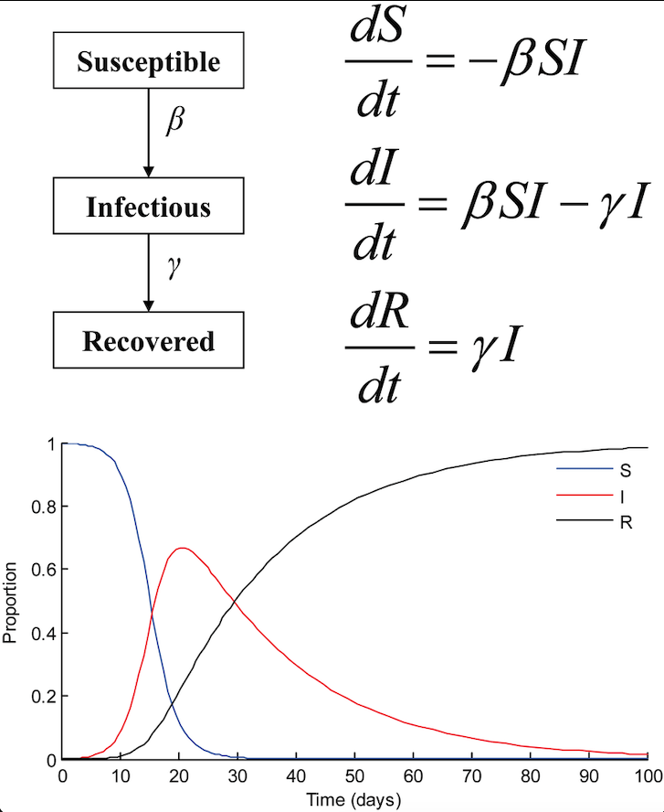

### 4.3.2 Parâmetros do Modelo

- $\beta$: Taxa de transmissão, ou seja, a probabilidade de que um contato entre um suscetível e um infectado resulte em uma nova infecção.
- $\gamma$: Taxa de recuperação, ou seja, a fração de infectados que se recupera por unidade de tempo (por exemplo, por dia). O inverso de $\gamma$ é o período infeccioso médio.

### 4.3.3 Aplicação do Modelo

O modelo SIR pode ser aplicado para prever o curso de uma epidemia e entender os efeitos de intervenções como a vacinação. A vacinação reduz o número de indivíduos suscetíveis ((S)), influenciando diretamente na propagação da doença.

### 4.3.5 Exemplo 1

```r
library(deSolve)
library(ggplot2)

# Parâmetros
N <- 10000000  # População total Portuguesa
I0 <- 1  # Número inicial de indivíduos infectados
R0 <- 0  # Número inicial de indivíduos recuperados
beta <- 2.14  # Taxa de transmissão
gamma <- 1/7  # Taxa de recuperação (1/7 dias)
days <- 160  # Duração da simulação em dias

# Função do modelo SIR
sir_model <- function(time, state, parameters) {
  with(as.list(c(state, parameters)), {
    dS <- -beta * S * I / N
    dI <- beta * S * I / N - gamma * I
    dR <- gamma * I
    list(c(dS, dI, dR))
  })
}

# Condições iniciais
initial_conditions_naive <- c(S = N - I0 - R0, I = I0, R = R0)
initial_conditions_60_vacc <- c(S = (1 - 0.6) * N - I0, I = I0, R = R0)
initial_conditions_95_vacc <- c(S = (1 - 0.95) * N - I0, I = I0, R = R0)

# Parâmetros do modelo
parameters <- c(beta = beta, gamma = gamma)

# Grid de tempo
times <- seq(0, days, by = 1)

# Soluções do modelo SIR
solution_naive <- as.data.frame(ode(y = initial_conditions_naive, times = times, func = sir_model, parms = parameters))
solution_60_vacc <- as.data.frame(ode(y = initial_conditions_60_vacc, times = times, func = sir_model, parms = parameters))
solution_95_vacc <- as.data.frame(ode(y = initial_conditions_95_vacc, times = times, func = sir_model, parms = parameters))

# Adicionar coluna de cenário
solution_naive$scenario <- "0% Vacinação"
solution_60_vacc$scenario <- "60% Vacinação"
solution_95_vacc$scenario <- "95% Vacinação"

# Combinar os dados
solution <- rbind(solution_naive, solution_60_vacc, solution_95_vacc)
```

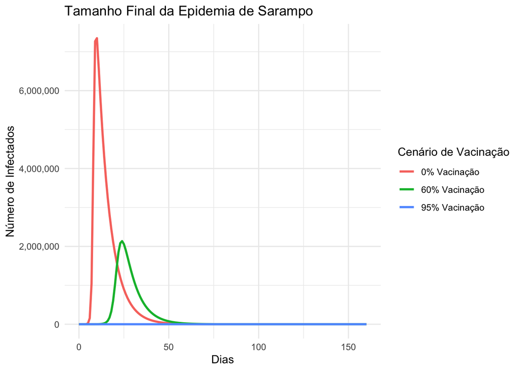

```r
# Plot dos resultados
ggplot(solution, aes(x = time, y = I, color = scenario)) +
  geom_line(size = 1) +
  scale_y_continuous(labels = scales::comma) +
  labs(title = "Tamanho Final da Epidemia de Sarampo",
       x = "Dias",
       y = "Número de Infectados",
       color = "Cenário de Vacinação") +
  theme_minimal()
```

Neste código, simulamos a evolução da epidemia de sarampo em uma população de 10.000.000 de pessoas sob três cenários diferentes de cobertura vacinal: sem vacinação, 60% de cobertura e 95% de cobertura. Utilizamos o pacote `deSolve` para resolver as equações diferenciais e o `ggplot2` para visualizar os resultados.